# NAFTA Natural Products harvest

Casey O’Hara

October 12, 2015

This script investigates the harvest of Natural Products for the Ocean Health Index, for the [three NAFTA member countries](http://news.bbc.co.uk/2/hi/business/4510792.stm): US, Canada, and Mexico.

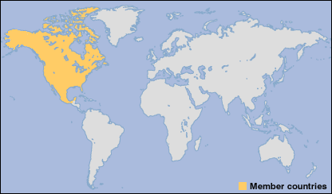

# Set up data frame

### Read and tidy raw data set

Read in the raw data set of commodity harvest quantity (in tonnes) downloaded from [FAO FishStatJ](http://www.fao.org/fishery/statistics/software/fishstatj/en).

```
##
## Reading FAO Commodity file: FAO_raw_commodities_quant_1950_2011.csv
```

```
##   country                                    commodity  trade year value
## 1 Albania   Albacore (=Longfin tuna), fresh or chilled Export 1976   ...
## 2 Albania      Anchovies minced, prepared or preserved Export 1976   ...
## 3 Albania     Anchovies nei, dried, salted or in brine Export 1976   ...
## 4 Albania                  Anchovies, fresh or chilled Export 1976   ...
## 5 Albania                            Anchovies, frozen Export 1976   ...
## 6 Albania Anchovies, prepared or preserved, not minced Export 1976   ...
```

### Clean up data for OHI Natural Products use

Convert FAO-specific codes into OHI-usable values. Assign commodities to OHI product groups. Because OHI treats the four islands of the Netherlands Antilles as separate regions, we must divide up the Antilles values across these separate regions, using the function `np_fix_antilles()` from `RMarkdown_fxn.R`.

```
## Loading and joining commodity-to-product lookup table.
```

```
## Dividing Netherlands Antilles value across subregions...
```

### Prepare and save data frame

```
## Writing cleaned harvest data to ~/github/rmarkdown_R/data/harvest_tonnes.csv.
```

Harvest data, in tonnes (head only)

| country | commodity | year | tonnes | product |
| --- | --- | --- | --- | --- |
| Albania | Coral and the like | 1996 | 315 | corals |
| Albania | Coral and the like | 1997 | 87 | corals |
| Albania | Coral and the like | 1998 | 221 | corals |
| Albania | Coral and the like | 1999 | 100 | corals |
| Albania | Coral and the like | 2000 | 27 | corals |
| Albania | Coral and the like | 2001 | 45 | corals |

# Examine NAFTA Natural Products harvests

Filtering the FAO data down to just the three countries of interest, we can inspect the product harvests by year and by product. Fish oil in particular is a concern; we would like to know the year and quantity of the maximum harvest across the three countries.

|  | country | product | year | tonnes |
| --- | --- | --- | --- | --- |
| 1 | Canada | corals | 1976 | 0 |
| 2 | Canada | corals | 1977 | 0 |
| 3 | Canada | corals | 1978 | 0 |
| 4 | Canada | corals | 1979 | 0 |
| 5 | Canada | corals | 1980 | 0 |
| 6 | Canada | corals | 1981 | 0 |
| 7 | Canada | corals | 1982 | 0 |
| 8 | Canada | corals | 1983 | 0 |
| 9 | Canada | corals | 1984 | 0 |
| 10 | Canada | corals | 1985 | 0 |

[output cut: 566 more lines]

**NOTE:** The US harvest of fish oil in 2011 was 6.764410^{4} tonnes.

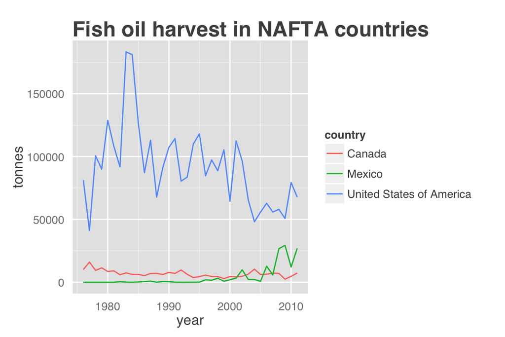

**NOTE:** The maximum harvest of fish oil across NAFTA countries was 1.832910^{5} tonnes in 1983, by United States of America.

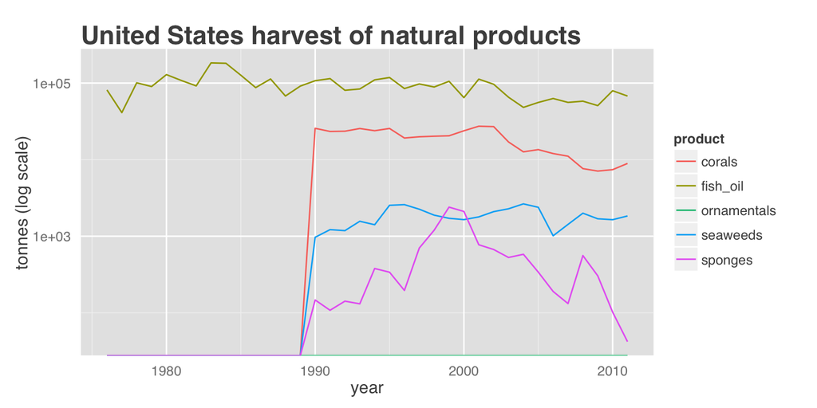